# Delays-Copy1

##### Andrew James Flight Delays Capstone 2

```python
from IPython.display import HTML

HTML('''<script>
code_show=true;
function code_toggle() {
 if (code_show){
 $('div.input').hide();
 } else {
 $('div.input').show();
 }
 code_show = !code_show
}
$( document ).ready(code_toggle);
</script>
<form action="javascript:code_toggle()"><input type="submit" value="Click here to toggle on/off the raw code."></form>''')
```

```python
import numpy as np
import pandas as pd
import seaborn as sns
import matplotlib.pyplot as plt
import statsmodels.api as sm
from sklearn.linear_model import LogisticRegression
from sklearn.metrics import classification_report, confusion_matrix
```

```python
df = pd.read_csv('/Users/drew/Downloads/flight_delay/2018.csv')
```

### Data Cleansing

```python
# df['CANCELLED'] = df['CANCELLED'].round(-1)
```

The key challenges we faced were centered around:

Inconsistent data types

- Some numerical Columns were actually classed as objects...

Renaming ..

Completely removing NaN values beyond using df.dropna..

### Dictionary

FL_DATE  
Date of the flight, yy/mm/dd  
OP_CARRIER  
Airline Identifier  
OP_CARRIER_FL_NUM  
Flight Number  
ORIGIN  
Starting Airport Code  
DEST  
Destination Airport Code  
CRS_DEP_TIME  
Planned Departure Time  
DEP_TIME  
Actual Departure Time  
DEP_DELAY  
Total Delay on Departure in minutes  
TAXI_OUT  
The time duration elapsed between departure from the origin airport gate and wheels off  
WHEELS_OFF  
The time point that the aircraft's wheels leave the ground  
WHEELS_ON  
The time point that the aircraft's wheels touch on the ground  
TAXI_IN  
The time duration elapsed between wheels-on and gate arrival at the destination airport  
CRS_ARR_TIME  
Planned arrival time  
ARR_TIME  
Actual Arrival Time  
ARR_DELAY  
Total Delay on Arrival in minutes  
CANCELLED  
Flight Cancelled (1 = cancelled)  
CANCELLATION_CODE  
Reason for Cancellation of flight: A - Airline/Carrier; B - Weather; C - National Air System; D - Security  
DIVERTED  
Aircraft landed on airport that out of schedule  
CRS_ELAPSED_TIME  
Planned time amount needed for the flight trip  
ACTUAL_ELAPSED_TIME  
AIR_TIME+TAXI_IN+TAXI_OUT  
AIR_TIME  
The time duration between wheels_off and wheels_on time  
DISTANCE  
Distance between two airports  
CARRIER_DELAY  
Delay caused by the airline in minutes  
WEATHER_DELAY  
Delay caused by weather  
NAS_DELAY  
Delay caused by air system  
LATE_AIRCRAFT_DELAY  
Delay caused by security

## Defining DataFrames

```python
# non_cdf is the main df with NO cancelled flights
non_cdf = df[df['CANCELLED']==0]
nan_clmns = ['CANCELLATION_CODE','CARRIER_DELAY','WEATHER_DELAY','NAS_DELAY','SECURITY_DELAY','LATE_AIRCRAFT_DELAY']
non_cdf.drop(columns=nan_clmns, inplace=True)
nan_test = non_cdf.isna()
any_nan = nan_test.any().any()
# print(f"cdf contains nan values... {any_nan}")
```

```python
# cl_df is the main df with dropped NaN values from the listed columns below
delay_colums = ['CARRIER_DELAY',
       'WEATHER_DELAY', 'NAS_DELAY', 'SECURITY_DELAY', 'LATE_AIRCRAFT_DELAY']
cl_df = df.dropna(subset=delay_colums)
```

```python
# cdf is the main df with ONLY cancelled flights
cdf = df[df['CANCELLED']==1]
```

### Taking a micro view of Airports and Airlines based on volume...

Upon examining the dataset, a need to focus on the busiest airports and airlines was needed to remove outliers. For airports, the 90th percentile in flight volume was taken. The 50th percentile in flight volume of airlines was taken due to fewer airlines than the number of airports in the dataset.  
***From this point forward, all airline/airport data is referencing a modified dataframe.

```python
# 90th,10th percentiles Airports based on airport traffic
departures = df['ORIGIN'].value_counts()
arrivals = df['DEST'].value_counts()
total_flights_airport = departures  + arrivals

airport_percentile_90 = np.percentile(total_flights_airport,90)
airport_percentile_10 = np.percentile(total_flights_airport,10)

# Defining Top Airports
airports_90 = total_flights_airport[total_flights_airport >= airport_percentile_90]
airports_10 = total_flights_airport[total_flights_airport <= airport_percentile_10]

top_airports_list = airports_90.index.tolist()
top_airports = df[df['ORIGIN'].isin(top_airports_list)] # filtering for only the busiest airports in the 90th percentile.




# Top 50th percentile was used for Airlines based on volume due to the limited number of airlines.
total_flights_airline = df['OP_CARRIER'].value_counts()

airline_percentile_50 = np.percentile(total_flights_airline,50)

# Defining Top Airlines
airline_50t = total_flights_airline[total_flights_airline >= airline_percentile_50]
airline_50b = total_flights_airline[total_flights_airline <= airline_percentile_50]

top_airline_list = airline_50t.index.tolist()
top_airlines = df[df['OP_CARRIER'].isin(top_airline_list)]


# Both top_airports and top_airlines include each other i.e top_airports only filters the 90th% of airports but includes all airlines.
```

# Summary

Flight Travel is synonymous with modern business today. As a flights Aviation Analyst, we seek to understand why airlines might have delays and whether this is man-made or subject to avoidance.

In our below presentation, we focus on analyzing the following core themes:

Flight Volume

Frequency of Cancellations Globally

Duration of Delays

### Volume Insights

```python
# cdf = cdf[['FL_DATE','OP_CARRIER_FL_NUM','ORIGIN','DEST','CRS_DEP_TIME','DISTANCE','DAY','Month']]
```

```python
# Industry Average Cancelled Flights (%)
perc_cancelled = round(df['CANCELLED'].mean()*100,2)
print(f"{perc_cancelled}% of flights cancelled annually")
```

```
1.62% of flights cancelled annually
```

```python
df['ORIGIN'].mean()
```

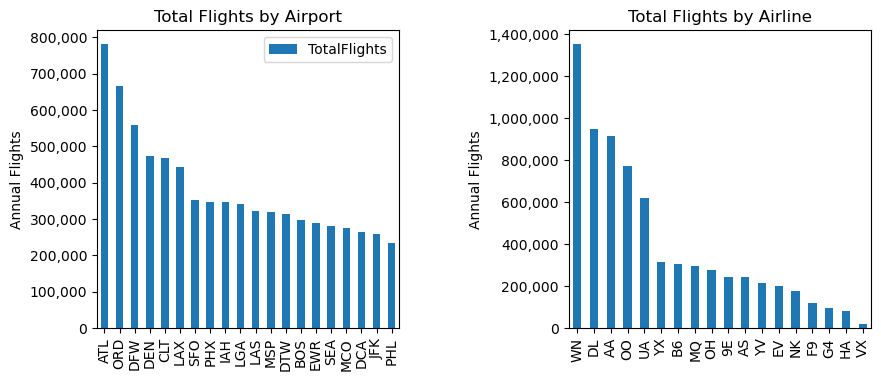

```python
# subplots
fig, axes = plt.subplots(nrows=1, ncols=2, figsize=(10, 5 ))

# Number of flights for each airport
departures = df['ORIGIN'].value_counts()
arrivals = df['DEST'].value_counts()
total_flights_airport = departures  + arrivals

top_airports = pd.DataFrame({'TotalFlights': total_flights_airport})
top_airports.sort_values(by='TotalFlights', ascending=False, inplace=True)
top_airports_20 = top_airports.head(20)


top_airports_20.plot(kind='bar', ax=axes[0])
axes[0].set_ylabel("Annual Flights")
axes[0].set_title("Total Flights by Airport")
labels1 = ['0', '100,000', '200,000', '300,000', '400,000', '500,000','600,000','700,000', '800,000']
axes[0].set_yticks([0,100000,200000,300000,400000,500000,600000, 700000, 800000], labels1)

# Number of flights for each airline

flights = df['OP_CARRIER'].value_counts()
flights.sort_values(ascending= False).head(20).plot(kind='bar', ax=axes[1])
labels = ['0', '200,000', '400,000', '600,000', '800,000', '1,000,000','1,200,000','1,400,000']
axes[1].set_yticks([0,200000,400000,600000,800000,1000000,1200000,1400000], labels)
axes[1].set_ylabel("Annual Flights")
axes[1].set_title("Total Flights by Airline")

plt.tight_layout(pad=5)
plt.show()
```

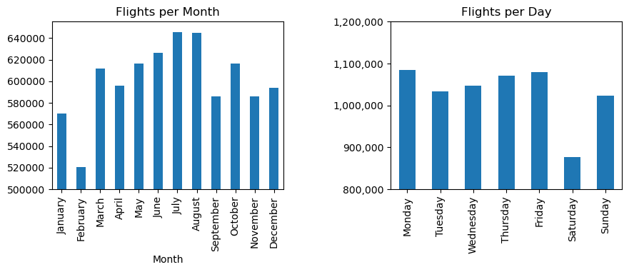

```python
# subplots
fig, axes = plt.subplots(nrows=1, ncols=2, figsize=(10, 5))

# Flights by month Industry Total
df['FL_DATE'] = pd.to_datetime(df['FL_DATE'])
# adding month column to df
df['Month'] = df['FL_DATE'].dt.month_name()

month_order = ['January','February','March','April','May','June','July','August','September','October','November','December']
df['Month'] = pd.Categorical(df['Month'], categories=month_order, ordered=True)
month_count = df['Month'].value_counts().sort_index()
month_count.plot(kind='bar', ax=axes[0])

axes[0].set_ylim(500000, month_count.max() + 10000)
axes[0].set_xlabel("Month")
axes[0].set_title("Flights per Month")



# Flights by Day Industry Total
# Adding Day column to df
df['DAY'] = df['FL_DATE'].dt.day_name()
# df['DAY'] = df['FL_DATE'].dt.weekday
day_count = df['DAY'].value_counts().sort_index()
# day_count
day_count = day_count.reindex(['Monday', 'Tuesday', 'Wednesday', 'Thursday', 'Friday','Saturday','Sunday'])
day_count.plot(kind='bar', ax=axes[1])

axes[1].set_ylim(800000, day_count.max()+1000)
axes[1].set_labels2 = ['800,000','900,000','1,000,000','1,100,000','1,200,000']
axes[1].set_yticks([800000,900000,1000000,1100000,1200000], labels2)
axes[1].set_title("Flights per Day")

plt.tight_layout(pad=5)
plt.show()
```